# AE 19: Inference using the Central Limit Theorem

2021-10-28

```r
library(tidyverse)
library(tidymodels)
```

# Bulletin

- Upcoming:
  - lab 08 tomorrow
- Due Saturday, 30th
  - homework 04

# Learning goals

- Use Central Limit Theorem (CLT) to conduct inference on a population mean
- Conduct CLT-based inference step-by-step and using `infer`
- Understand $t$ distribution vs. standard normal, $N(0,1)$ distribution.

# Review

Suppose the distribution of the number of minutes users engage with apps on an iPad has a mean of 8.2 minutes and standard deviation of 1 minute. Let $x$ be the number of minutes users engage with apps on an iPad, $\mu$ be the population mean and $\sigma$ the population standard deviation. Then,

$$x \sim N(8.2, 1)$$

Suppose you take a sample of 60 randomly selected app users and calculate the mean number of minutes they engage with apps on an iPad, $\bar{x}$. The conditions (independence & sample size/distribution) to apply the Central Limit Theorem are met. Then by the Central Limit Theorem

$$\bar{x} \sim N(8.2, 1/\sqrt{60})$$

- What is the probability a randomly selected user engages with iPad apps for more than 8.3 minutes? Use `pnorm` for calculations.

  ```r
  #add code
  ```

- What is the probability the mean minutes of app engagement for a group of 60 randomly selected iPad users is more than 8.3 minutes? Use `pnorm` for calculations.

  ```r
  #add code
  ```

- What is the probability the mean minutes of app engagement for a group of 60 randomly selected iPad users is between 8.3 and 8.4 minutes? Use `pnorm` for calculations.

```r
    #add code
```

# Data: Pokemon

We will be using the `pokemon` dataset, which contains information about 42 randomly selected Pokemon (from all generations). You may load in the dataset with the following code:

```r
pokemon <- read_csv("data/pokemon.csv")
```

In this analysis, we will use CLT-based inference to draw conclusions about the mean height among all Pokemon species.

## Exercise 1

Let’s start by looking at the distribution of `height_m`, the typical height in meters for a Pokemon species, using a visualization and summary statistics.

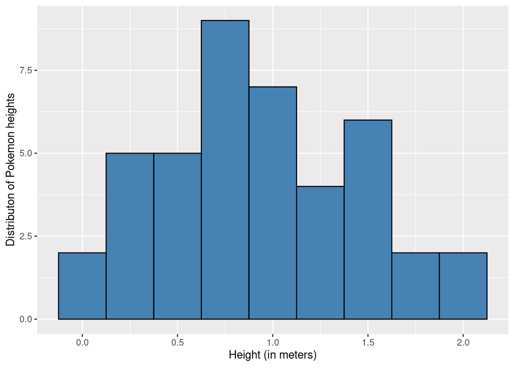

```r
ggplot(data = pokemon, aes(x = height_m)) +
  geom_histogram(binwidth = 0.25, fill = "steelblue", color = "black") +
  labs(x = "Height (in meters)",
       y = "Distributon of Pokemon heights")
```

```r
pokemon %>%
  summarise(mean_height = mean(height_m),
            sd_height = sd(height_m),
            n_pokemon = n())
```

| mean_height | sd_height | n_pokemon |
| --- | --- | --- |
| 0.9285714 | 0.4974499 | 42 |

In the previous lecture (and in the review questions), we were given the mean, $\mu$, and standard deviation, $\sigma$, of the population. That is unrealistic in practice (if we knew $\mu$ and $\sigma$, we wouldn’t need to do statistical inference!).

Today we will use our sample data and the Central Limit Theorem to draw conclusions about the $\mu$, the mean height in the population of Pokemon.

- What is the point estimate for $\mu$, i.e., the “best guess” for the mean height of all Pokemon?
- What is the point estimate for $\sigma$, i.e., the “best guess” for the standard deviation of the distribution of Pokemon heights?

## Exercise 2

Before moving forward, let’s check the conditions required to apply the Central Limit Theorem. Are the following conditions met:

- Independence?
- Sample size/distribution?

## Exercise 3

By the Central Limit Theorem,

$$\bar{x} \sim N(\mu, \sigma/ \sqrt{n}) \hspace{2mm} \Rightarrow \hspace{2mm} Z = \frac{\bar{x} - \mu}{\sigma/\sqrt{n}}$$

where $Z$ is a standardized score such that $Z \sim N(0,1)$.

- Describe the distribution of $Z$ in words.

In practice, we can’t calculate the standardized score $Z$, so instead we will use the standardized score $T$ when conducting inference for a population mean…

$$Z = \frac{\bar{x} - \mu}{\sigma/\sqrt{n}} \hspace{4mm} \Rightarrow \hspace{4mm} T = \frac{\bar{x} - \mu_0}{s/\sqrt{n}}$$

- How do $Z$ and $T$ differ?
- What is the estimated standard error $s/\sqrt{n}$ for the Pokemon data?

```r
# add code
```

$T$ is a new standardized score that follows a $t$ distribution with $n-1$ degrees of freedom. It is written as $t_{n-1}$. We will use the $t_{n-1}$ distribution to help us conduct hypothesis tests and construct confidence intervals.

## Exercise 4

The mean height of humans is about 1.65 meters. We would like to test whether the mean height of Pokemon is less than the mean height of humans.

- State the null and alternative hypotheses in words and statistical notation.
- Calculate the $T$ test statistic.

$$T = \frac{\bar{x} - \mu_0}{s/\sqrt{n}}$$

where $\mu_0$ is the null hypothesized value.

```r
# add code
```

- What is the distribution of the test statistic, $T$?
- Now let’s calculate the p-value. Fill in the code below to use the `pt()` function to calculate the p-value. For `x` input the value of the test statistic, and for `df` input the degrees of freedom.

```r
#pt(x = ____, df = ____)
```

- State with the p-value means.
- State the conclusion in the context of the data using a significance level of $\alpha = 0.05$.

## Exercise 5

We would like to construct a 90% confidence interval for the mean height of Pokemon species. The equation general equation for a confidence interval is

$$\text{estimate} \pm crit^* \times SE$$

Specifically, the confidence interval for the mean is

$$\bar{x} \pm t^*_{n-1} \times \frac{s}{\sqrt{n}}$$

The second part of the equation, $t^*_{n-1} \times \frac{s}{\sqrt{n}}$ is called the **margin of error**.

We already know $\bar{x}$ and $s/\sqrt{n}$, so let’s talk about $t_{n-1}$. This value is determined based on the confidence level, $C$. It is the point on the $t$ distribution with $n-1$ degrees of freedom, such that the area between $-t^*$ and $t^*$ is $C$.

- What is the critical value $t^*$ for our 90% confidence interval of the mean Pokemon height?

```r
## add code
```

- Now calculate the 90% confidence interval for the mean Pokemon height.

```r
# add code
```

- Interpret the interval in the context of the data.

## CLT-based calculations in infer

### Hypothesis test

- Conduct the hypothesis test from Exercise 4 using the `t_test()` function.

```r
pokemon %>%
  t_test(response = height_m,
         alternative = "less",
         mu = 1.65,
         conf_int = FALSE)
```

| statistic | t_df | p_value | alternative | estimate |
| --- | --- | --- | --- | --- |
| -9.398718 | 41 | 4.38446e-12 | less | 0.9285714 |

### Confidence interval

```r
pokemon %>%
  t_test(response = height_m,
         conf_int = TRUE,
         conf_level = 0.9) %>%
  select(lower_ci, upper_ci)
```

| lower_ci | upper_ci |
| --- | --- |
| 0.7993968 | 1.057746 |